# Looping Functions, Assignment #4

Author

Kyle Alves

# Assignment 4

For this assignment you will write a new Quartro document based on the analysis of power required for different *possible_cars* from looping.RMD; You will

Put the Quatro in your assignment github and submit a link on Canvas for Assignment 4 when its ready to be graded

**Grading Rubric**

1. Correct R code for adding the super light car (5pts)
2. Values for mean and maximum power for all 4 cars are in expected ranges (remember you are sampling so values will differ slightly) (5pts)
3. Used both methods (**FOR** and **pmap**) correctly (4pts)
4. Boxplots (6pts)
1. correctly show range of power consumption for each car type for the two methdos
2. good presentation (e.g axis labels, colors)
5. Good coding practice (e.g Adequate documentation throughout) (5pts)

Total out of 25pts

```r
library(tidyverse)
```

```r
source("R/autopower.R")
# generate a structure to store info on our possible cars

#Add an additional super light car with mass 5,000 kg and a surface area 10m2
possible_cars = data.frame(name = c("A","B","C", "splt"),mass=c(10000,65000,38000, 5000), area = c(22,30,22, 10))
```

```r
#Compute the mean and maximum power for Cars A, B, C and for your new car, assuming that average highway speed is 80 km/hr with a standard deviation of 10km/hr; Use 2 different methods to compute the mean and maximum power for each car type;

#make object speeds
nsample = 200
mean_speed = 80*0.277
speeds = rnorm(mean = mean_speed, sd=10*0.277, nsample)
summary(speeds)
```

[output not shown]

```
   Min. 1st Qu.  Median    Mean 3rd Qu.    Max.
  14.59   20.43   22.20   22.32   24.46   30.37
```

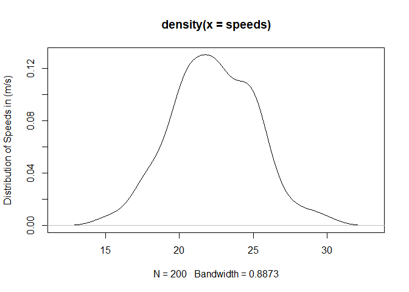

```r
plot(density(speeds), ylab="Distribution of Speeds in (m/s)")
```

```r
#a) FOR loop
powerfor = as.data.frame(matrix(nrow = length(speeds), ncol = nrow(possible_cars)))

#checking powerfor rows and columns
nrow(possible_cars)
```

```
[1] 4
```

```r
ncol(powerfor)
```

```
[1] 4
```

```r
#index into matrix
for (i in 1:ncol(powerfor)) {
  powerfor[,i] =
    autopower(A=possible_cars$area[i],
              m=possible_cars$mass[i],
              V=speeds)
}

head(powerfor)
```

```
        V1       V2       V3       V4
1 81412.19 284111.7 175772.0 38537.36
2 67682.97 251011.3 154204.4 32169.55
3 59838.86 231089.8 141331.5 28522.42
4 61469.16 235301.8 144046.0 29281.06
5 81790.26 284996.7 176351.4 38712.48
6 75231.29 269453.8 166195.2 35672.73
```

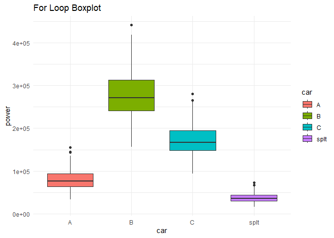

```r
#adding column names
colnames(powerfor) = possible_cars$name

#pivot_longer for plotting
powerforlong = powerfor |>
  pivot_longer(cols = everything(),
               names_to = "car",
               values_to = "power")

#Create forloop boxplot

forloopplot = ggplot(powerforlong, aes(car, power, fill = car)) +
  geom_boxplot() +
  labs(title = "For Loop Boxplot") +
  theme_minimal()

forloopplot
```

```r
#Compute the mean and maximum power for Cars A, B, C and for your new car, assuming that average highway speed is 80 km/hr with a standard deviation of 10km/hr

#b) the pmap function from purr
powerpurr <- pmap(list(A=possible_cars$area, m=possible_cars$mass), autopower, V=speeds)

#add column names
powerpurr <- as.data.frame(powerfor, col.names=possible_cars$name)

#check
powerpurr
```

[output not shown]

```
            A        B         C     splt
1    81412.19 284111.7 175771.99 38537.36
2    67682.97 251011.3 154204.42 32169.55
3    59838.86 231089.8 141331.49 28522.42
4    61469.16 235301.8 144045.98 29281.06
5    81790.26 284996.7 176351.44 38712.48
6    75231.29 269453.8 166195.23 35672.73
7    75067.83 269061.0 165939.18 35596.92
8   127404.35 384665.0 242390.17 59777.72
9    79621.02 279901.4 173017.11 37707.54
10   89818.90 303505.7 188501.74 42428.77
11   63972.03 241692.6 148172.13 30445.08
12   93898.70 312719.9 194571.74 44315.53
13   94095.02 313160.3 194862.21 44406.30
14   72751.41 263465.1 162294.17 34522.44
```

[output cut: 186 more lines]

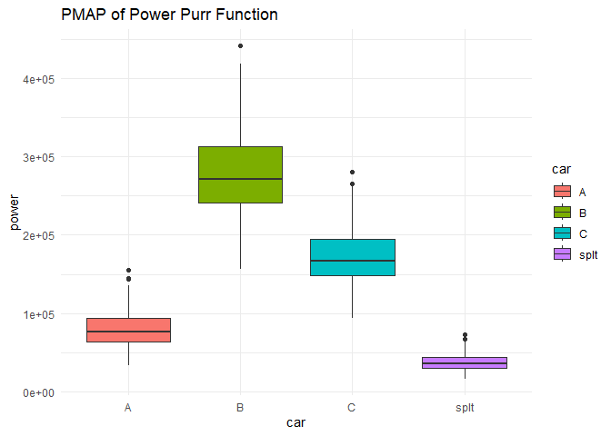

```r
#pivot to longer rows for plotting
powerpurrlong <- powerpurr |>
  pivot_longer(cols = everything(), names_to = "car", values_to = "power")

powerpurrplot <- ggplot(powerpurrlong, aes(car, power, fill = car)) +
  geom_boxplot() +
  labs(title = "PMAP of Power Purr Function") +
  theme_minimal()

powerpurrplot
```